# My Wordle Experience

## An Overview

Over the past two months, I’ve been collecting data of my Wordle daily games performance, with the purpose of analysing my knowledge of the English language vocabulary as well as my deduction skill. In following sections, I will be presenting some data I thought would be interesting to look at.

#### An overview of my performance over the past 2 months:

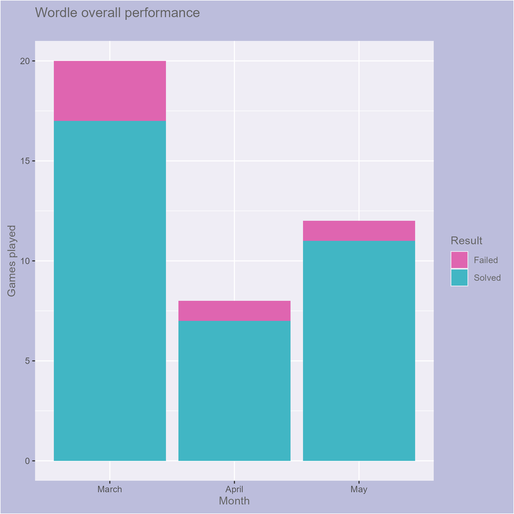

Overall performance plot

–

Overall, I have a positively high win-rate, with only 5 losses out of 40 games played, translating to a 87.5% win-rate, and the month I was most active in collecting data for this story is March (Around the time for project 2). The month I had collected the least data for is April, which makes sense, since I only started collecting data again at the end of April in preparation to create this story.

## First letters habit

In this plot, I summarised the average guesses needed for each first letter I used, the total numbers of games I played using that first letter, and the amount of failed games of that letter.

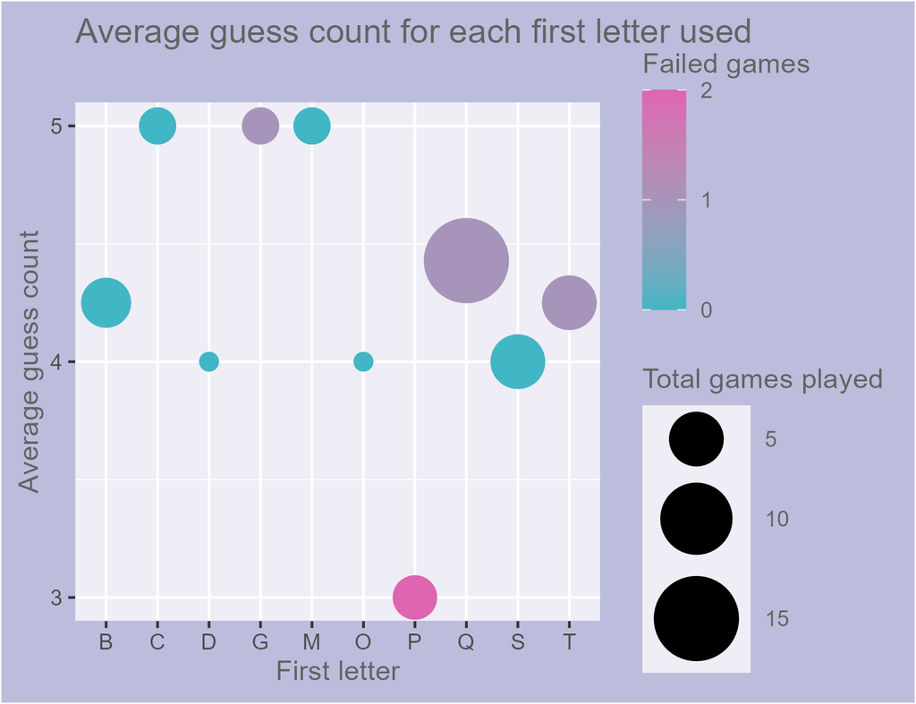

Guess count vs first letters plot

–

A couple of facts that can be inferred looking at this data:

- The word I’m most comfortable using to start off a game starts with ‘Q’ (The word is ‘Quota’!)
- I dislike starting with the letter ‘P’, with only a couple of total games played, and is responsible for 2 of my losses.
- Other starting letters seems to have been experimented with, but none nearly used as common as ‘Q’.

## Yellow tiles vs Win rate

This following plot shows the amount of yellow tiles I got for each games, and how many games I won/lost with that amount.

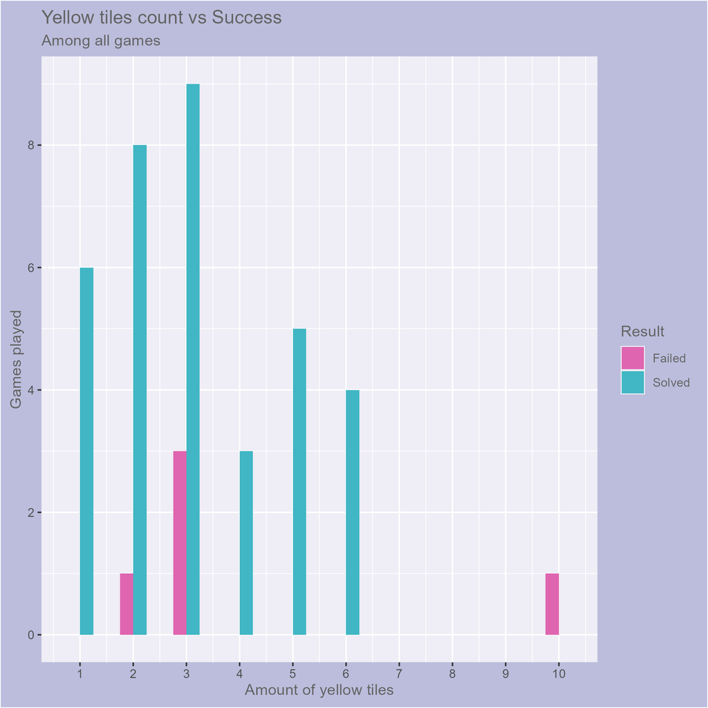

Yellow tiles count vs Success plot

–

From this visualized data, it can be deducted that:

- there is 1 particularly unlucky game where I had as many as 10 yellow tiles in total, yet I couldn’t find the word at all.
- Most of the games I played have surprisingly low amount of yellow tiles. When I first carried out this survey, I had expected the number of yellow tiles per game to be more around 6, but instead, the number hovers around 2 & 3. This means that my ability to deduct the correct letter positions & correct words are quite good, or I have a good understanding of the structures of common English words.
- 3 out of my 5 losses have only 3 yellow tiles, which means I was not close at all to solving the word during those days, or was very close (most tiles are green, or almost no green tiles), which is rather polarizing compared to what I had expected (again, I expected way more yellow tiles per game.)

## Difficulty vs Guess Count

Last but not least, I have prepared a visualization of how I thought how difficult the word of the day was to guess, and how many tries it took me to guess the word:

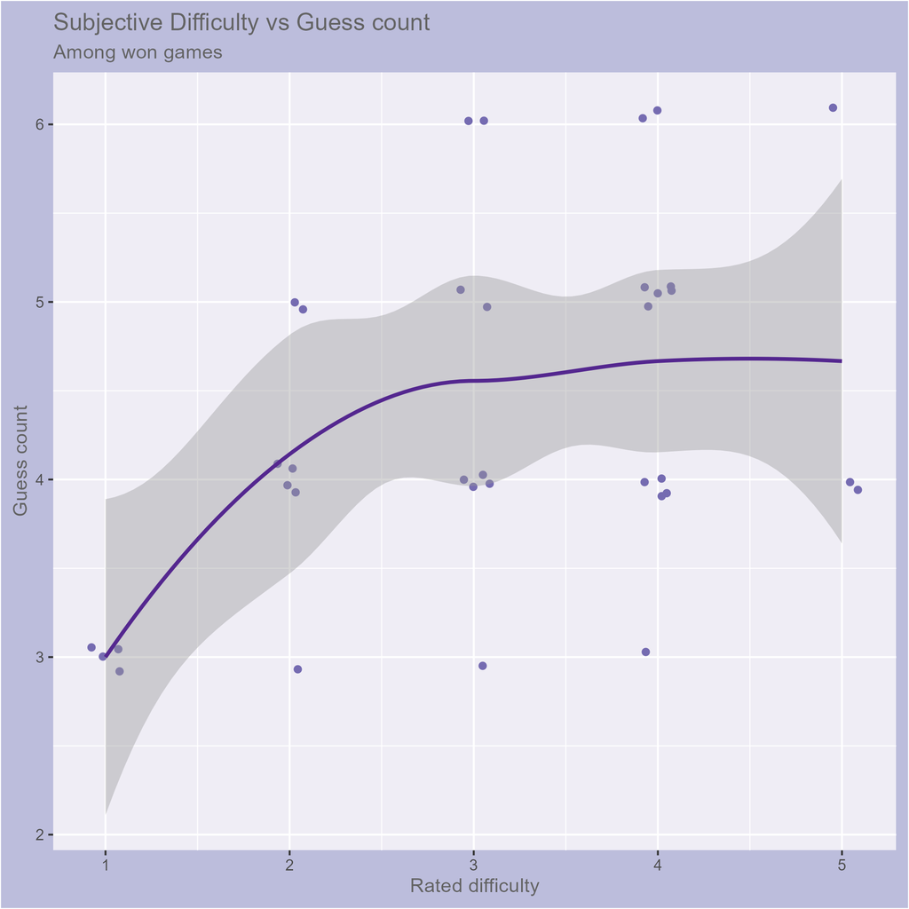

Subjective difficulty vs Guess count plot

–

This plot shows that:

- All of my games played during this period all required 3 or more guesses to get, and 4 guesses is the most common occurrence among all games.
- There are 2 games where I had rated 3 out of 5 for difficulty, and yet required all 6 guesses to get the word, and similarly, 2 games with 2 out of 5 difficulty but required 5 guesses. This means I either tunnel-visioned the letter structure of such words in hindsight, or it was a word I knew, but not commonly used.
- There is only 1 game where I had rated 5 out of 5 difficulty, and needed all 6 guesses, which means for all the words that I consider ‘hard to guess’, I got quite lucky for most of them, with the rest only require 4.